# Curriculum Vitae

Moses Lahai

2026-11-17

| **Moses Lahai** | Chopinstraat 46, 8031ZK Zwolle |
| --- | --- |
|  | Phone: 0685575804 |
|  | Email: lahai_moses@hotmail.com, moses.lahai@student.hu.nl |
|  | LinkedIn: https://www.linkedin.com/in/moses-lahai-71a881439/ |

## PROFILE

I am a dedicated fourth-year HBO Life Sciences student at Hogeschool Utrecht, specialising in Biomolecular Research. My background spans molecular biology, protein biochemistry and data analysis, with hands-on experience in techniques including SDS-PAGE, Western blot, mass spectrometry, and PCR. I have contributed to research projects in both academic and applied settings, and I am comfortable working independently as well as in a team. I am looking for an internship where I can apply and deepen my laboratory skills within a professional research environment with a particular interest in molecular biology, proteomics or clinical diagnostics.

## PROJECT EXPERIENCE

[output not shown]

| **Promotion Research – Chemistry Lecturer Hanan Al Habobe (6 months, 10 EC) Student Researcher** | **2021 – 2022** |
| --- | --- |
| Hogeschool Utrecht, Utrecht, Netherlands – Quantification of cortisol and cortisone in human saliva to support early detection of potential health risks |  |

## WORK EXPERIENCE

| **Parcel Sorter • FedEx, Zwolle** | **2026 – Present** |
| --- | --- |
| **Netherlands Care Support Assistant (hand- and spans service) • Driezorg, Zwolle, Netherlands, Elderly care assistance** | **2018 – 2021** |

## EDUCATION

| **B Biology and Medical Laboratory Research HBO bachelor**, *Hogeschool Utrecht, Utrecht, Netherlands* • Weighted average grade: 7.2 | **2018 – Present** |
| --- | --- |
| **Minor Data Science for Biology 1**, *Hogeschool Utrecht, Utrecht, Netherlands* | **2025 (15 EC)** |
| **Minor Applied Bioanalytical and Pharmaceutical Chemistry**, *Hogeschool Utrecht, Utrecht, Netherlands* | **2021 – 2022 (15 EC)** |
| **Bachelor Nursing (HBO)**, *Christelijke Hogeschool Windesheim, Zwolle, Netherlands* | **2016 – 2017** |
| **Higher General Secondary Education (HAVO)**, *Scholengemeenschap van der Capellen, Zwolle, Netherlands* | **2012 – 2016** |
| **Higher General Secondary Education**, *Gymnasium Celeanum, Zwolle, Netherlands* | **2011 – 2012** |

## SKILLS

**Laboratory Techniques**

- SDS-PAGE and Western blot
- Sterile technique & pipetting
- BCA-assay
- DNA-isolation and PCR (basic)
- Basic experience with mass spectrometry

**Research**

- Formulating research questions based on scientific literature
- Using databases and search engines
- Efficient scientific literature reading
- Designing and planning research workflows
- Selecting appropriate biomedical research methods and techniques
- Performing laboratory techniques independently and collaboratively
- Applying basic biomedical research techniques correctly and safely

**Collaboration & Communication**

- Effective teamwork
- Critical and respectful interaction with team members
- Communicating scientific findings

**Software & Data Analysis**

- R (data wrangling, RNA-seq analysis, metagenomics, GO-enrichment analysis)
- Python (scripting and data analysis)
- Excel
- Bash (command-line, used in bioinformatics workflows)

## LANGUAGE

- Dutch – Fluent
- English – Fluent

## INTERESTS & HOBBIES

- Reading
- Drawing
- Sports and exercising
- Spending time with friends and family
- Watching movies

# Journey to becoming a clinical bioinformatician

## Where I stand now

To see where my skills compare with what employers ask for, I analysed 17 vacancies (11 in the Netherlands and 6 abroad) for (junior) bio-informaticians and noted which skills each one requires

```r
library(tidyverse)
Vacancy_skillset <- tibble(
  skills = c("Python", "R", "Bash/Linux", "Git", "Statistics/ML", "Snakemake/Nextflow", "Dockers/Containers", "NGS data analysis and file formats (fastq, bam"),
  frequency_in_vacancies = c(5, 3, 7, 1, 2, 9, 1, 8),
  Do_I_have_it = c("Yes", "Yes", "Yes", "Yes", "Partly", "No", "No", "Basic"))

Vacancy_skillset
```

```
## # A tibble: 8 × 3
##   skills                                     frequency_in_vacancies Do_I_have_it
##   <chr>                                                       <dbl> <chr>
## 1 Python                                                          5 Yes
## 2 R                                                               3 Yes
## 3 Bash/Linux                                                      7 Yes
## 4 Git                                                             1 Yes
## 5 Statistics/ML                                                   2 Partly
## 6 Snakemake/Nextflow                                              9 No
## 7 Dockers/Containers                                              1 No
## 8 NGS data analysis and file formats (fastq…                      8 Basic
```

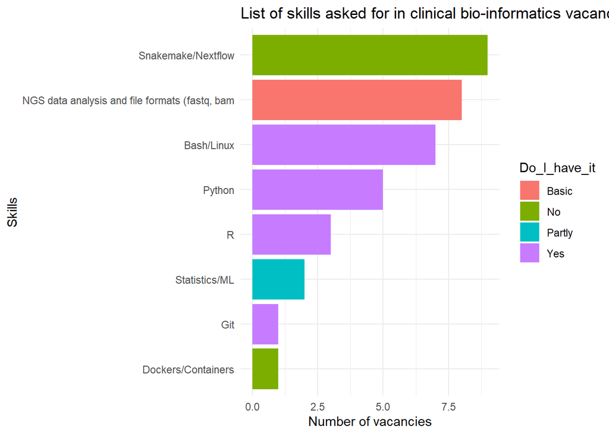

```r
ggplot(Vacancy_skillset, aes(x = reorder(skills, frequency_in_vacancies), y = frequency_in_vacancies, fill = Do_I_have_it)) +
  geom_col() +
  coord_flip() +
  labs(title = "List of skills asked for in clinical bio-informatics vacancies",
       x = "Skills",
       y = "Number of vacancies") +
  theme_minimal()
```

## Current Strenghts

On the data side I work in R (RNA-seq analysis, metagenomics, GO enrichment), Python and Bash, and I use Git and RMarkdown for reproducible reporting. On the lab side I have hands-on experience with SDS-PAGE, Western blot, BCA assays, PCR and sterile technique, which helps me understand how the data I analyse is produced

## What I still want to learn

Out of the 17 vacancies most ask for experience in snakemake and nextflow. However for this course I will be tackling machine learning/statistics and using that on NGS data analysis. I chose machine learning first I cause I am curious about what expression data can predict, and it builds on the R/Python skills I already have. Aside from that by using the machine learning skill on for NGS data analysis, which is also one of the most requested skills, I will have a complete and full skillset

# Learning machine learning for biology: predicting cancer type from RNA-seq data

## Why this skill

In my vacancy analysis, statistics and machine learning were requested in several vacancies and are only partly covered by my current skills. I apply the skill to a biological question: **can a machine learning model distinguish cancer types (or subtypes) based on gene and which genes and processes drive it**

## Plan (32 hours)

[output not shown]

## How I will show I learned the skill

- A reproducible analysis (Rmd or notebook, with code in a GitHub repository). with the code explained step by step
- Data preparation and a proper **train/test split**
- At least two models
- Evaluation with a PCR matrix, plus a figure of the most important genes with a GO enrichment plot and whether they make biological sense.
- A reflection on limitations: many more genes than samples, overfitting, and what the model can and cannot say.

## Learning log

## Data and preparation

## Models and results

## Reflection

## Credits

# Data management

## Organising RNA-seq data from the DAUR2 module

For the formative RNA-seq assignment of the DAUR2 module I was asked to organise the data files according to the Guerrilla Analytics principles. I no longer have access to the DAUR2 files, so I could not carry out this exercise. Instead, I applied the same principles to my own portfolio repository (next section).

For an RNA-seq project I would store each dataset in its own folder in *data-raw/*, with the raw fastq files (not renamed or changed), md5 checksums to check file integrity, and a *README.txt* describing the source, the files and the processing. Files such as bam and count files would be produced by code and stored in a separate folder

## Applying Guerrilla Analytics to this portfolio

Some folders are still empty, because the data for my free assignment is added later. Figure 1 shows the folder structure, created with `fs::dir_tree()`, and Figure 2 shows the README file of the repository.

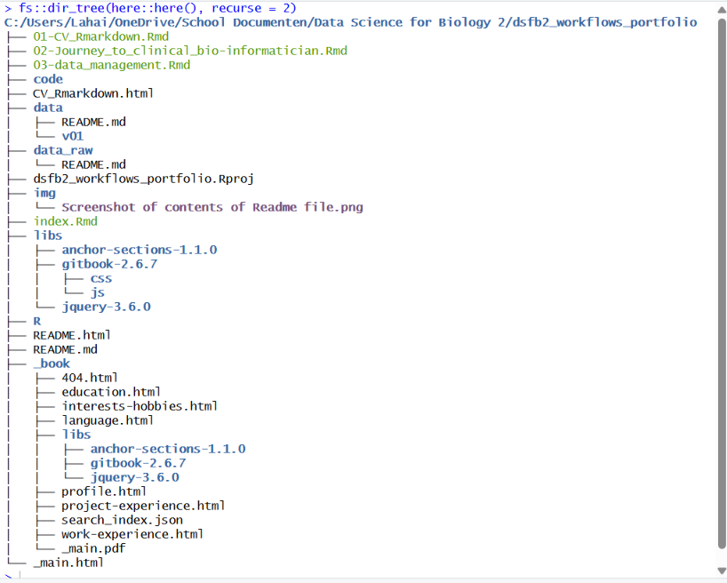

fig1: Folder structure of my portfolio repository.

[figure not shown]